# Технологии и инструменты разработки FrontEnd

## Термины и определения

Фронтенд (англ. front-end) — клиентская сторона пользовательского интерфейса к программно-аппаратной части сервиса.

Бэкенд (англ. back-end) — программно-аппаратная часть сервиса.

Фронтенд — все, что браузер может читать, выводить на экран и / или запускать. То есть это HTML, CSS и JavaScript.

HTML (HyperText Markup Language) говорит браузеру, каково содержание страницы, например, «заголовок», «параграф», «список», «элемент списка».

CSS (Cascading Style Sheets) говорит браузеру, как отображать элементы, например, «после первого параграфа отступ в 20 пикселей» или «весь текст в элементе body должен быть темно-серым и написан шрифтом Verdana».

JavaScript говорит браузеру, как реагировать на некоторые взаимодействия, используя легкий язык программирования. Большинство сайтов на самом деле не используют много JavaScript, но если вы нажмете на что-то и содержимое страницы поменяется без белого мигания экрана, значит, где-то использовался JavaScript.

Бэкенд — все, что работает на сервере, то есть «не в браузере» или «на компьютере, подсоединенном к сети (обычно к Интернету), который отвечает на сообщения от других компьютеров».

Для бэкенда вы можете использовать любые инструменты, доступные на вашем сервере (который, по сути, является просто компьютером, настроенным для ответов на сообщения). Это означает, что вы можете использовать любой универсальный язык программирования: Ruby, PHP, Python, Java, JavaScript / Node, bash. Это также означает, что вы можете использовать системы управления базами данных, такие как MySQL, PostgreSQL, MongoDB, Cassandra, Redis, Memcached.

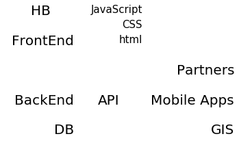

```python
plt.text(0.3, 0.8, "FrontEnd", size=20, rotation=0., ha="right", va="top")
plt.text(0.3, 0.4, "BackEnd",  size=20, rotation=0., ha="right", va="top")
plt.text(0.3, 0.2, "DB",       size=20, rotation=0., ha="right", va="top")
plt.text(0.5, 0.4, "API",      size=20, rotation=0., ha="right", va="top")
for i, tool in enumerate(["GIS","Mobile Apps","Partners"]):
    plt.text(1, 0.2+i*0.2, tool, size=20, rotation=0., ha="right", va="top")
for i, tool in enumerate(["html","CSS","JavaScript"]):
    plt.text(0.6, 0.8+i*0.1, tool, size=15, rotation=0., ha="right", va="top")
plt.text(0.2, 1, "HB", size=20, rotation=0., ha="right", va="top")
plt.axis('off')
plt.show()
```

## HTML

HTML-документ — это обычный текстовый документ HTML-документ имеет расширение .html HTML-документ состоит из дерева HTML-элементов и текста. Элементы выделяются тегами

```python
<!DOCTYPE html> <!-- Объявление формата документа -->
<html>
<body> <!-- Основная часть документа -->
  <H3>Привет, друзья!</H3>
  Мы сегодня изучим технологии фронтэнда
  <ol>
    <li>HTML</li>
    <li>CSS</li>
    <li>JavaScript</li>
  </ol>
</body>
</html>
```

<!DOCTYPE html>

### Привет, друзья!

Мы сегодня изучим технологии фронтэнда

1. HTML
2. CSS
3. JavaScript

## Объектная модель документа, DOM (document object model).

```python
Объектная модель документа, DOM (document object model), состоит из элементов внутри тега <html>
<html> является корневым элементом.
Родственные отношения: предок, потомок, родительский элемент, дочерний элемент, сестринский элемент
```

[figure not shown]

### Тег $<html>$

#### Элемент $<head>$

```python
Раздел <head>...</head> содержит техническую информацию о странице:
заголовок, описание, ключевые слова для поисковых машин, кодировку и т.д.
Введенная в нем информация не отображается в окне браузера, однако содержит данные,
которые указывают браузеру, как следует обрабатывать страницу.
```

```python
  <head> <!-- Техническая информация о документе -->
    <meta charset="UTF-8"> <!-- Определяем кодировку символов документа -->
    <title>Самый лучший заголовок!</title> <!-- Задаем заголовок документа -->
    <link rel="stylesheet" type="text/css" href="style.css"> <!-- Подключаем внешнюю таблицу стилей -->
    <script src="script.js"></script> <!-- Подключаем сценарии -->
  </head>
```

#### Элемент $<title>$

```python
Обязательным тегом раздела <head> является тег <title>.
Текст, размещенный внутри этого тега, отображается в строке заголовка веб-браузера.
Длина заголовка должна быть не более 60 символов, чтобы полностью поместиться в заголовке.

<title>Самый лучший заголовок!</title>
```

#### Элемент $<meta>$

```python
Необязательным тегом раздела <head> является одинарный тег <meta>.
С его помощью можно задать описание содержимого страницы и ключевые слова
для поисковых машин, автора HTML-документа и прочие свойства метаданных.
Элемент <head> может содержать несколько элементов <meta>,
потому что в зависимости от используемых атрибутов они несут различную информацию.
```

```python
<meta name="description" content="Описание содержимого страницы">
<meta name="keywords" content="Ключевые слова через запятую">
<meta name="keywords" lang="ru" content="Ключевые слова через запятую">
<meta name="keywords" lang="en" content="Keywords">
```

#### Элемент $<style>$

Используется для задания стилей CSS.

```python
<html>
<head>
<style type="text/css">
.info {width: 400px; height: 30px; background-color: yellow; color: red;}
</head>
<body>
<h4>Прикольный заголовок</h4>
<div class="info">Блок документа.</div>
</body>
</html>
```

### Прикольный заголовок

Блок документа.

#### Элемент $<link>$

```python
Задать стили для документа можно также при помощи другого способа — записать их в отдельный файл с расширением .css, например, style.css.

Подключить файл со стилями к веб-странице можно двумя способами:
через директиву @import url

<link rel="stylesheet" href="style.css" type="text/css">
```

#### Элемент $<script>$

```python
Элемент <script> позволяет присоединять к документу исполняемые скрипты JS.
```

```python
<html>
<head>
<script> function f_press() { alert('Нажата кнопка'); }
</script>
</head>
    <body>
        <h4>Нажми кнопку</h4>
        <input type="button" value="Press" onclick="f_press()">
    </body>
</html>
```

#### Нажми кнопку

### Элемент $<body>$

#### Теги

```python
<!-- Используется для добавления комментариев. -->
```

```python
<a> Создаёт гипертекстовые ссылки.
<a href="https://www.usurt.ru">	Ссылка на сайт УрГУПС </a>
```

[Ссылка на сайт УрГУПС](https://www.usurt.ru)

```python
<abbr> Определяет текст как аббревиатуру или акроним. Поясняющий текст задаётся с помощью атрибута title.
<abbr title="Уральский государственный университет путей сообщения"> УрГУПС </abbr>
```

УрГУПС

#### Теги

```python
<b>	Задает полужирное начертание отрывка текста, не придавая акцент или важность выделенному. </b>
```

**Задает полужирное начертание отрывка текста, не придавая акцент или важность выделенному.**

```python
<blockquote> Выделяет текст как цитату, применяется для описания больших цитат. </blockquote>
```

> Выделяет текст как цитату, применяется для описания больших цитат.

#### Теги

```python
<button> Создает интерактивную кнопку. Внутрь тега можно поместить содержимое - текст или изображение.
<button style="color: blue">Нажми меня</button>
<button style="color: red">Или меня</button>
```

```python
<del> Помечает текст как удаленный, перечёркивая его. </del>
```

Помечает текст как удаленный, перечёркивая его.

```python
<div> Тег-контейнер для разделов HTML-документа. Используется для группировки блочных элементов с целью форматирования стилями.
<div class="text"> Тег-контейнер для разделов HTML-документа.</div>
```

#### Теги

```python
<h1-h6>	Создают заголовки шести уровней для связанных с ними разделов.
<h1>Первый</h1> <h2>Второй</h2> <h3>Третий</h3> <h4>Четвертый</h4> <h5>Пятый</h5> <h6>Шестой</h6>
```

# Первый

## Второй

### Третий

#### Четвертый

##### Пятый

###### Шестой

#### Теги

```python
<i> Выделяет отрывок текста курсивом, не придавая ему дополнительный акцент. </i>
```

*Выделяет отрывок текста курсивом, не придавая ему дополнительный акцент.*

```python
<img> Встраивает изображения в HTML-документ с помощью атрибута src, значением которого является адрес встраиваемого изображения.
<img src="me.jpg" width="100" height="100">
```

#### Теги

```python
<input>	Создает многофункциональные поля формы, в которые пользователь может вводить данные.
```

```python
<input>	Создает многофункциональные поля формы, в которые пользователь может вводить данные.
```

```python
<ins> Выделяет текст подчеркиванием. Применяется для выделения изменений, вносимых в документ. </ins>
```

Выделяет текст подчеркиванием. Применяется для выделения изменений, вносимых в документ.

#### Теги

```python
<ol> Нумерованный список
<ol> <li>Первый</li><li>Второй</li> <ol>
```

1. Первый
2. Второй

```python
<ul> Ненумерованный список
<ul> <li>Первый</li><li>Второй</li> <ul>
```

- Первый
- Второй

#### Теги

```python
Параграфы в тексте
<p> Параграф 1 </p>
<p> Параграф 2 </p>
```

Параграф 1

Параграф 2

```python
<select> Выбор значений из <option>.
<select>
  <option>Пункт 1</option>
  <option>Пункт 2</option>
</select>
```

#### Теги

```python
Контейнер для строчных <span style="color: red"> элементов </span>.
Можно использовать для <span style="font-size: 42px"> форматирования </span>.
```

Контейнер для строчных элементов . Можно использовать для форматирования .

Надстрочное написание <sup>символов</sup>.

#### Теги

```python
<table>, <tr>, <td>, <th>, <thead>	Теги для создания таблицы.
<table>
    <thead><th>Страна</th><th>Столица</th></thead>
    <tr><td>Россия</td><td>Москва</td></tr>
    <tr><td>Япония</td><td>Токио</td></tr>
</table>
```

| Россия | Москва |
| --- | --- |
| Япония | Токио |

#### Аттрибуты

- "class" определяет имя класса для элемента (используется для определения класса в таблице стилей).
- "id" определяет уникальный идентификатор элемента.
- "style" указывает на код CSS, применяемый для оформления элемента.

## CSS

```python
CSS (Cascading Style Sheets) — язык таблиц стилей, который позволяет прикреплять стиль (например, шрифты и цвет) к структурированным документам (например, документам HTML и приложениям XML).
Объявление стиля состоит из двух частей: селектора и объявления.
<head>
<style>
h1 {
color: red;
font-family: "Times New Roman", Georgia, Serif;
line-height: 1.3em;
}
</style>
</head>
<body>
<h1>Привет</h1>
</body>
```

## JavaScript

### Переменные

let message; message = 'Hello!'; alert(message); // показывает содержимое переменной

### Функции

function showMessage() { alert( 'Всем привет!' ); }

### Объекты и классы

class MyClass { // методы класса constructor() { ... } method1() { ... } method2() { ... } method3() { ... } ... }

### Условный оператор if

if (year == 2015) { alert( "Правильно!" ); alert( "Вы такой умный!" ); }

### Цикл while

while (condition) { // код // также называемый "телом цикла" }

### Цикл for

for (let i = 0; i < 3; i++) { // выведет 0, затем 1, затем 2 alert(i); }

# Домашнее задание

1. "Крестики-нолики": три на три
2. "Наперстки": случайно загадывается один вариант из трех
3. "Найди пару": в таблице три на три загаданы варианты, надо найти пару
4. "Однорукий бандит": случайно выбирается три значения

**Полезные ссылки**

- http://htmlbook.ru/html/time
- https://html5book.ru/osnovy-css/
- https://learn.javascript.ru/
- https://plnkr.co